# The Five-Star Movement in Parliament

SISP Conference 2017, Urbino 14-16

## The essentials

- Co-founded in 2009 by Beppe Grillo, a comedian and political activist, and a web strategist Gianroberto Casaleggio
- In 2013, second most-voted party for the Chamber of Deputies
- Direct "internet" democracy, anti-establishment, environmentalism and euroscepticism

[figure not shown]

## A new kind of opposition party

1. post-ideological
2. representing neglected or unheard voices
3. refusing dialogue with other parties (except when it fits its agenda)

## The literature on the 5SM

- Political communication
- Democratic theory
- Party organization
- Electoral demand and party supply
- … what characterises the agenda of the 5SM in parliament? (Pinto & Pedrazzani 2015)

## The agenda of the 5SM

1. A left or right-wing agenda?
2. To which extent it deals with issues neglected by other opposition parties?
3. Agenda-setter? Agenda-taker?

## Data

- Content coding of parliamentary activities in the Chamber of Deputies (1262 bills, 1065 oral questions and 1383 written questions)
- 4 "main" opposition parties: 5SM, Forza Italia, Lega Nord, Sinistra Ecologia e Libertà
- Letta and Renzi cabinets
- One of the 230 policy codes (aggregated in 21 policy areas) making up the Italian Policy Agendas codebook (http://www.comparativeagendas.net/italy)

## 1.A left or right-wing agenda?

## Convergence of 5SM agenda in the current legislature with opposition parties of the past

- question time content coded at subtopic level (Russo and Cavalieri 2016)
- convergence score = \((\sum_{i=1}^n (\lvert x_{ip}-x_{im5s}\rvert)/2\) (Sigelman and Buell 2004)

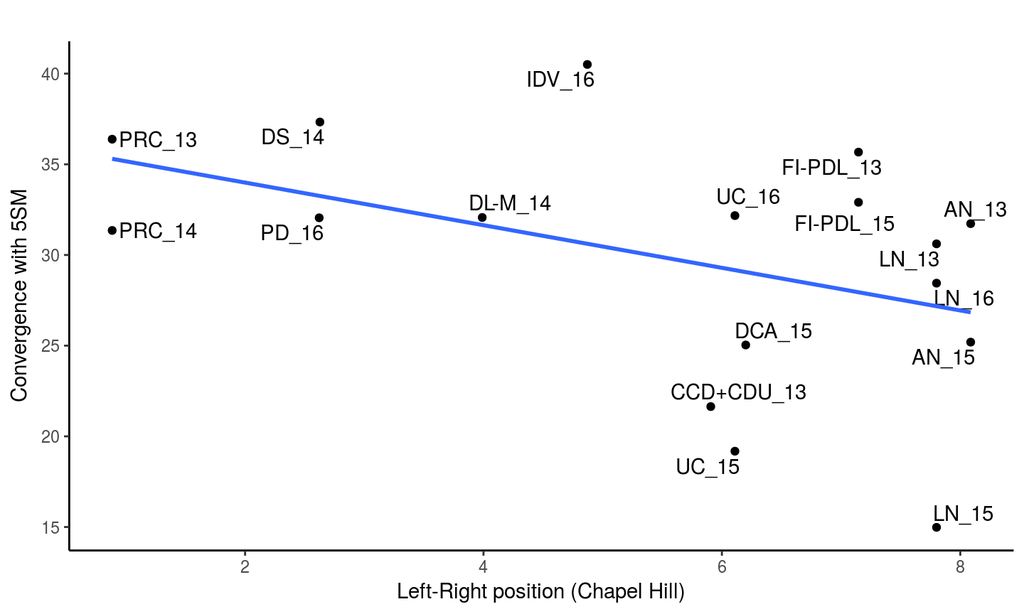

## 2. To which extent it deals with issues neglected by other opposition parties?

## Distribution of attention across issues and type of activity

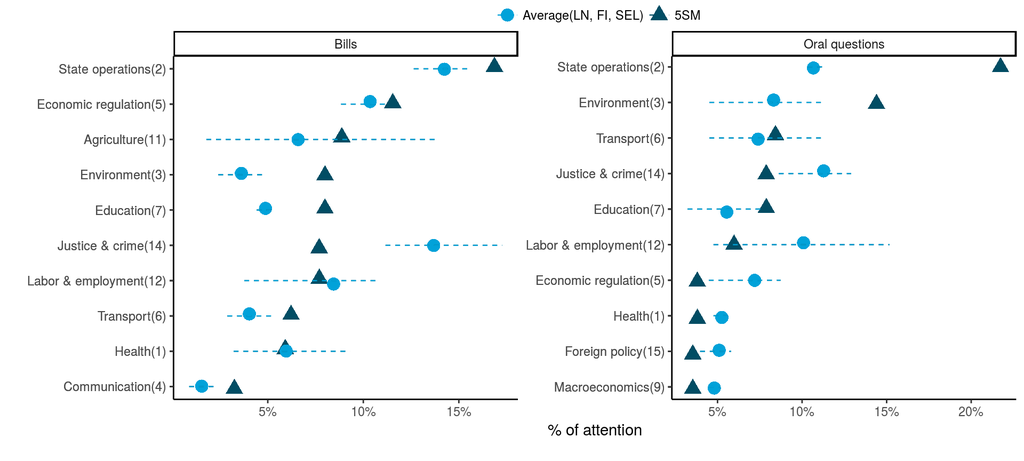

## 3. Agenda-setter or taker?

## Bills

|  | **\(FI_{it}\)** | **\(5SM_{it}\)** | **\(LN_{it}\)** | **\(SEL_{it}\)** |  |
| --- | --- | --- | --- | --- | --- |
| (Intercept) | 0.03*** | 0.03*** | 0.03*** | 0.03*** |  |
|  | (0.00) | (0.00) | (0.00) | (0.00) |  |
| \(FI_{it-1}\) | 0.12* | 0.11* | 0.02 | 0.05 |  |
|  | (0.05) | (0.05) | (0.05) | (0.05) |  |
| \(5SM_{it-1}\) | 0.10* | 0.08 | 0.06 | 0.18*** |  |
|  | (0.04) | (0.05) | (0.05) | (0.05) |  |
| \(LN_{it-1}\) | 0.07 | 0.11** | 0.05 | -0.00 |  |
|  | (0.04) | (0.04) | (0.05) | (0.04) |  |
| \(SEL_{it-1}\) | 0.06 | 0.05 | 0.10* | 0.10 |  |
|  | (0.04) | (0.04) | (0.04) | (0.05) |  |
| R<sup>2</sup> | 0.05 | 0.05 | 0.02 | 0.04 |  |
| Adj. R<sup>2</sup> | 0.04 | 0.04 | 0.02 | 0.04 |  |
| Num. obs. | 945 | 945 | 945 | 945 |  |
| ***p < 0.001, **p < 0.01, *p < 0.05 |  |  |  |  |  |

## Oral questions

|  | **\(FI_{it}\)** | **\(5SM_{it}\)** | **\(LN_{it}\)** | **\(SEL_{it}\)** |  |
| --- | --- | --- | --- | --- | --- |
| (Intercept) | 0.04*** | 0.02*** | 0.03*** | 0.04*** |  |
|  | (0.00) | (0.00) | (0.00) | (0.00) |  |
| \(FI_{it-1}\) | 0.08 | 0.05 | 0.09* | 0.02 |  |
|  | (0.05) | (0.04) | (0.04) | (0.04) |  |
| \(5SM_{it-1}\) | 0.16** | 0.30*** | -0.03 | 0.09* |  |
|  | (0.05) | (0.05) | (0.05) | (0.05) |  |
| \(LN_{it-1}\) | -0.00 | 0.03 | 0.13** | 0.04 |  |
|  | (0.03) | (0.02) | (0.05) | (0.03) |  |
| \(SEL_{it-1}\) | -0.03 | 0.09** | 0.11* | 0.10* |  |
|  | (0.04) | (0.03) | (0.05) | (0.05) |  |
| R<sup>2</sup> | 0.03 | 0.13 | 0.03 | 0.02 |  |
| Adj. R<sup>2</sup> | 0.02 | 0.13 | 0.03 | 0.02 |  |
| Num. obs. | 966 | 966 | 966 | 966 |  |
| ***p < 0.001, **p < 0.01, *p < 0.05 |  |  |  |  |  |

## Preliminary conclusions

- the 5SM profile cross-cuts the left-right axis
- it differs only for a few issues from other opposition parties in the current legislature
- both agenda-setter and agenda-taker - different relationship with different opposition parties
- **TO DO:**
- work on theory and how to generalize this analysis beyond the Italian case
- run more formalised statistical tests
- incorporate info on manifesto priorities